# Remote Data Access with Pandas

## Introduction

In this notebook, we will explore how to work with financial data stored on remote servers using Pandas, a powerful yet easy-to-use Python library for data analysis. In this presentation, we will see how Pandas can help you connect to remote data sources, pull in the financial information you need, and then organize and analyze that data. We will go through clear examples that show how to retrieve data from a distance and use Pandas to make sense of it, making the process both straightforward and effective. By the end of this talk, you'll understand the basics of remote data access and how Pandas can be a valuable tool in your financial analysis toolkit.

There are several free sources of financial and economic data that can be accessed remotely. One of the most widely used is Yahoo Finance, which provides historical stock prices, exchange rates, and market data through its API. The Federal Reserve Economic Data (FRED) platform offers a vast collection of economic indicators, including GDP, inflation, and interest rates. Another key resource is Alpha Vantage, which provides free access to stock market and forex data with an API key. Quandl (now part of Nasdaq Data Link) also offers various economic and financial datasets, though some may require a subscription.

In this presentation, we will focus only on Yahoo Finance and FRED, as they are completely free and do not require an API key or registration, making them the easiest options for retrieving financial and economic data with Pandas.

## What is `pandas-datareader`

`pandas-datareader` is an extension to the popular `pandas` library in Python, designed to simplify the process of accessing and importing data from various financial and economic sources. It is particularly useful in data science and finance applications where real-time or historical data is required for analysis.

### Key Features of `pandas-datareader`

1. **Data Acquisition from Multiple Sources**:
   - Fetch financial data such as stock prices, indices, and exchange rates.
   - Access macroeconomic data like GDP, unemployment rates, and inflation.
   - Supported sources include Yahoo Finance, Alpha Vantage, World Bank, and FRED (Federal Reserve Economic Data).
2. **Seamless Integration with `pandas`**:
   - The data retrieved is returned as a `pandas.DataFrame` or `pandas.Series`, enabling immediate compatibility with pandas' analytical tools.
   - Built-in functionality to handle time-series data efficiently.
3. **Ease of Use**:
   - Simple API for fetching data with minimal setup.
   - Provides clear error messages for unsupported sources or connectivity issues.
4. **Customizable Queries**:
   - Retrieve data for specific time periods, tickers, or categories.
   - Filter results based on user-defined criteria.

### Installation

To use `pandas-datareader`, install it via pip:

```
pip install pandas-datareader
```

### Core Functions

Here are some of the key functionalities provided by `pandas-datareader`, for the full list follow this [link](https://pandas-datareader.readthedocs.io/en/latest/) to the documentation web page.

#### Accessing Macroeconomic Data

Fetch economic indicators such as interest rates or GDP data from FRED. The St. Louis [FRED](https://fred.stlouisfed.org/) (Federal Reserve Economic Data) is a comprehensive online database managed by the Federal Reserve Bank of St. Louis. It provides free access to a vast collection of economic and financial data that spans across various sectors, geographies, and time periods.

FRED is widely used by economists, researchers, analysts, and students to retrieve historical data for analysis, visualization, and forecasting.

[figure not shown]

```python
# Example: Retrieve US unemployment rate data
unemployment_data = pdr.get_data_fred('UNRATE', start='2020-01-01', end='2023-01-01')
print(unemployment_data.head())
```

```
            UNRATE
DATE
2020-01-01     3.6
2020-02-01     3.5
2020-03-01     4.4
2020-04-01    14.8
2020-05-01    13.2
```

```python
# Example: Fetching the U.S. 10-Year Treasury Yield
# The FRED series ID for the 10-year Treasury yield is "DGS10".
import pandas_datareader as pdr
import datetime

# Define the time period
start_date = datetime.datetime(2010, 1, 1)
end_date = datetime.datetime(2024, 2, 1)
# Fetch 10-Year Treasury Yield data from FRED
interest_rates = pdr.data.DataReader("DGS10", "fred", start_date, end_date)
# Display the first few rows
interest_rates.head(5)
```

| DATE | DGS10 |
| --- | --- |
| 2010-01-01 | NaN |
| 2010-01-04 | 3.85 |
| 2010-01-05 | 3.77 |
| 2010-01-06 | 3.85 |
| 2010-01-07 | 3.85 |

```python
# Example: Fetching Multiple Interest Rate Series
# You can request multiple interest rate series at once by passing a list of series IDs.

# List of interest rate series IDs
series_ids = ["DGS10", "DGS2", "DGS3MO"]  # 10Y, 2Y, and 3-Month Treasury rates
# Fetch data
rates = pdr.data.DataReader(series_ids, "fred", start_date, end_date)
# Print the first few rows
rates.head()
```

| DATE | DGS10 | DGS2 | DGS3MO |
| --- | --- | --- | --- |
| 2010-01-01 | NaN | NaN | NaN |
| 2010-01-04 | 3.85 | 1.09 | 0.08 |
| 2010-01-05 | 3.77 | 1.01 | 0.07 |
| 2010-01-06 | 3.85 | 1.01 | 0.06 |
| 2010-01-07 | 3.85 | 1.03 | 0.05 |

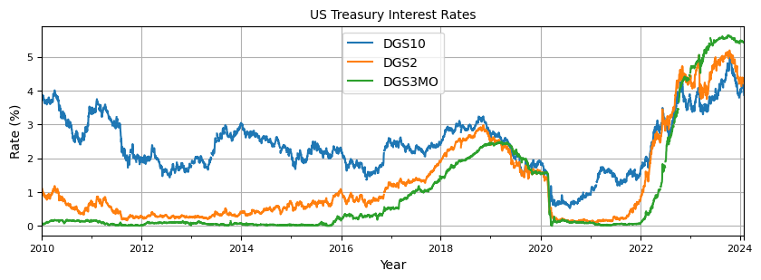

```python
# Example: Plotting the Interest Rate Data
# To visualize how interest rates change over time:
import matplotlib.pyplot as plt

# Plot the interest rate trends
rates.plot(figsize=(10, 3), fontsize=8)
plt.title("US Treasury Interest Rates", fontsize=10)
plt.xlabel("Year")
plt.ylabel("Rate (%)")
plt.grid()
plt.show()
```

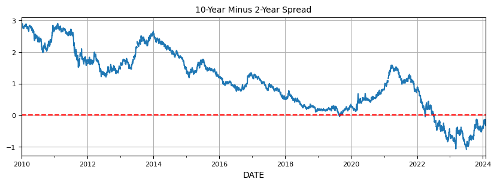

```python
# Example: Calculating Interest Rate Spread
# You can analyze the yield curve by computing spreads, such as the 10-Year minus 2-Year Treasury yield:
# Calculate the yield spread (10Y - 2Y)
rates["Spread_10Y_2Y"] = rates["DGS10"] - rates["DGS2"]
# Plot the spread
rates["Spread_10Y_2Y"].plot(figsize=(10, 3), fontsize=8)
plt.title("10-Year Minus 2-Year Spread", fontsize=10)
plt.axhline(0, color="red", linestyle="--")  # Mark zero line
plt.grid()
plt.show()
```

#### World Bank Data

Retrieve global economic indicators from the World Bank:

[figure not shown]

```python
# Example: Retrieve World Bank GDP data for a specific country
from pandas_datareader import wb

gdp_data = wb.download(indicator='NY.GDP.MKTP.CD', country=['US'], start=2010, end=2022)
# Format the GDP with points separating thousands
gdp_data['NY.GDP.MKTP.CD'] = gdp_data['NY.GDP.MKTP.CD'].apply(lambda x: f"{x:,.0f}")
# Print the formatted GDP data
print(gdp_data.head())
```

```
                        NY.GDP.MKTP.CD
country       year
United States 2022  26,006,893,000,000
              2021  23,681,171,000,000
              2020  21,354,105,000,000
              2019  21,539,982,000,000
              2018  20,656,516,000,000
```

[figure not shown]

**Python Pills**

The format string `f"{x:,.0f}"` in Python is an **f-string** with specific formatting instructions for numbers. Let's break it down:

**Explanation of `f"{x:,.0f}"`**

- `f""` → This is an **f-string**, meaning that any expression inside `{}` will be evaluated and formatted in place.
- `x` → This is the variable being formatted.
- `:` → This separates the value from the format specification.
- `,` → This adds a **thousands separator** (commas in English notation).
- `.0f` → This means:
  - `.0` → Round to **zero decimal places**.
  - `f` → Format the number as a **fixed-point decimal**.

**Example Usage**

```
x = 1234567.89

formatted_x = f"{x:,.0f}"
print(formatted_x)  # Output: "1,234,568"
```

- The number is rounded to `1,234,568` because `.0f` means no decimal places.
- The comma separator makes it easier to read large numbers.

**Comparison with Other Formats**

| Format String | Explanation | Example Output (if `x = 1234567.89`) |
| --- | --- | --- |
| `f"{x:,.2f}"` | Adds thousands separator and keeps **2 decimal places** | `"1,234,567.89"` |
| `f"{x:.0f}"` | No separator, rounded to **0 decimal places** | `"1234568"` |
| `f"{x:,}"` | Adds separator but keeps **default decimal places** (if float) | `"1,234,567.89"` |

### Some Others Example with FRED

#### The VIX Index

**What is the VIX Index?**

The **VIX Index**, often referred to as the "Fear Index" or "Fear Gauge," is a financial benchmark that represents the market's expectation of volatility over the next 30 days. It is derived from the prices of options on the **S&P 500 Index (SPX)**. The VIX is widely used as a measure of market sentiment, particularly investor fear or uncertainty.

**Key Features of the VIX Index**

**1. Calculation**

- The VIX is calculated by the Chicago Board Options Exchange (CBOE) using a weighted average of the implied volatilities of a wide range of SPX call and put options.
- It reflects the market's expectations of future price fluctuations, not the actual or historical volatility of the S&P 500.

**2. Volatility as an Asset Class**

- A higher VIX indicates increased market uncertainty and fear, often correlating with significant market downturns or events.
- A lower VIX suggests calm market conditions, indicating lower expected price swings.

**Interpreting VIX Values**

- **Low VIX (<15)**: Suggests stability and investor confidence in the market.
- **Moderate VIX (15–25)**: Indicates average levels of market uncertainty or expected volatility.
- **High VIX (>25)**: Reflects elevated uncertainty, often due to geopolitical events, economic crises, or market shocks.

**Why the VIX Matters**

1. **Market Sentiment Indicator**:
   - The VIX is often used as a barometer for investor sentiment. A rising VIX signals fear and potential risk-off behavior, while a declining VIX suggests confidence.
2. **Hedging and Speculation**:
   - Traders and portfolio managers use the VIX for hedging portfolios or speculating on future market volatility via derivatives such as VIX futures, options, or exchange-traded products (ETPs).
3. **Leading Indicator**:
   - The VIX can sometimes act as a leading indicator for equity market movements, as spikes in the VIX often precede sharp market declines.

**Practical Applications**

1. **Portfolio Protection**: Investors use VIX options or futures to hedge against downside risks in their equity portfolios.
2. **Volatility-Based Strategies**: Quantitative traders use the VIX in strategies like volatility arbitrage or pairs trading with other volatility instruments.
3. **Economic Analysis**: Economists and analysts observe the VIX to gauge market reactions to macroeconomic news, Federal Reserve decisions, or geopolitical developments.

```python
# Setting the beginning and end of the historical data
start_date = '1990-01-01'
end_date   = '2023-01-23'
# Creating a dataframe and downloading the VIX data
vix = pdr.DataReader('VIXCLS', 'fred', start_date, end_date)
# Calculating the number of nan values
count_nan = vix['VIXCLS'].isnull().sum()
# Printing the result
print('Number of nan values in the VIX dataframe: ' + str(count_nan))
# Printing the latest five observations of the dataframe
vix.tail()
```

```
Number of nan values in the VIX dataframe: 292
```

| DATE | VIXCLS |
| --- | --- |
| 2023-01-17 | 19.36 |
| 2023-01-18 | 20.34 |
| 2023-01-19 | 20.52 |
| 2023-01-20 | 19.85 |
| 2023-01-23 | 19.81 |

```python
# Dropping the NaN values from the rows
vix = vix.dropna()
# Taking the differences in an attempt to make the data stationary
# (see appendix for a description of the diff method)
vix = vix.diff(periods = 1, axis = 0)
# Dropping the first value of the data frame
# This statement modifies vix by selecting a subset of its rows and
# columns using .iloc[], which is used for integer-based indexing in Pandas.
# Remember python slicing-> [1:, ] (Row selection) → Excludes the first row (index 0) and keeps all rows from index 1 onward.
#                           [, : ] (Column selection) → Selects all columns.
vix = vix.iloc[1: , :]
# Calculating the mean of the dataset
mean = vix["VIXCLS"].mean()
# Printing the result
print('The mean of the dataset = ' + str(mean))
```

```
The mean of the dataset = 0.00030844935189630385
```

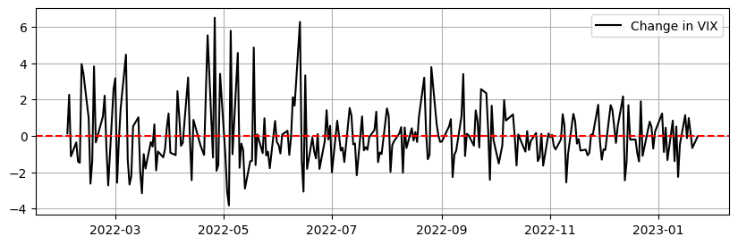

```python
plt.figure(figsize=(10,3))
# Plotting the latest 250 observations in black with a label
# Note the negative index ...
plt.plot(vix[-250:], color = 'black', linewidth = 1.5, label = 'Change in VIX')
# Plotting a red dashed horizontal line that is equal to mean
plt.axhline(y = mean, color = 'red', linestyle = 'dashed')
# Calling a grid to facilitate the visual component
plt.grid()
# Calling the legend function so it appears with the chart
plt.legend()
# Calling the plot
plt.show()
```

#### CPIAUCSL Data in the FRED Database

The CPIAUCSL is a dataset in the FRED (Federal Reserve Economic Data) database representing the **Consumer Price Index for All Urban Consumers: All Items, Seasonally Adjusted**. It is a key economic indicator published by the Bureau of Labor Statistics (BLS) and provides a measure of the average change in prices paid by urban consumers for a broad basket of goods and services over time. The CPIAUCSL measures inflation by tracking the price changes of goods and services consumed by urban households, which comprise about 93% of the U.S. population.

**Data Characteristics**

- Frequency: Monthly
- Units: Index (1982–1984 = 100) The base period is set to 1982–1984, meaning the average index value during that period is 100.
- Seasonal Adjustment: The data is adjusted for predictable seasonal patterns to provide a clearer picture of underlying trends.

```python
# Setting the beginning and end of the historical data
start_date = '1950-01-01'
end_date   = '2023-01-23'

# Creating a dataframe and downloading the CPI data
cpi = pdr.DataReader('CPIAUCSL', 'fred', start_date, end_date)

# Printing the latest five observations of the dataframe
print(cpi.tail())
```

```
            CPIAUCSL
DATE
2022-09-01   296.421
2022-10-01   297.979
2022-11-01   298.708
2022-12-01   298.808
2023-01-01   300.456
```

```python
# Checking if there are nan values in the CPI dataframe
count_nan = cpi['CPIAUCSL'].isnull().sum()

# Printing the result
print('Number of nan values in the CPI dataframe: ' + str(count_nan))

# Transforming the CPI into a year-on-year measure
# The pct_change() method in Pandas calculates the
# percentage change between consecutive elements in
# a Series or DataFrame.
cpi = cpi.pct_change(periods = 12, axis = 0) * 100

# Dropping the nan values from the rows
cpi = cpi.dropna()
```

```
Number of nan values in the CPI dataframe: 0
```

```python
print("\n" + 100*"-")
print("Dataframe BEFORE index resetting")
print(100*"-")
cpi.head()
```

```
----------------------------------------------------------------------------------------------------
Dataframe BEFORE index resetting
----------------------------------------------------------------------------------------------------
```

| DATE | CPIAUCSL |
| --- | --- |
| 1951-01-01 | 7.954062 |
| 1951-02-01 | 9.402795 |
| 1951-03-01 | 9.475465 |
| 1951-04-01 | 9.598309 |
| 1951-05-01 | 9.339504 |

```python
# Resetting the index
cpi = cpi.reset_index()
print("\n"+100*"-")
print("Dataframe AFTER index resetting")
print(100*"-")
cpi.head()
```

```
----------------------------------------------------------------------------------------------------
Dataframe AFTER index resetting
----------------------------------------------------------------------------------------------------
```

|  | DATE | CPIAUCSL |
| --- | --- | --- |
| 0 | 1951-01-01 | 7.954062 |
| 1 | 1951-02-01 | 9.402795 |
| 2 | 1951-03-01 | 9.475465 |
| 3 | 1951-04-01 | 9.598309 |
| 4 | 1951-05-01 | 9.339504 |

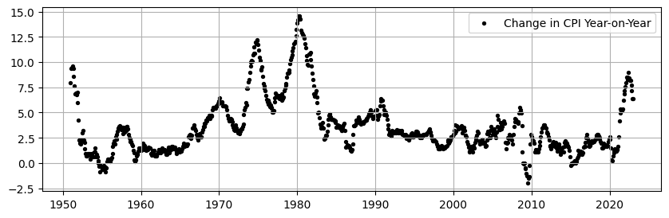

```python
# Creating the chart
fig, ax = plt.subplots(figsize=(10,3))
ax.scatter(cpi['DATE'], cpi['CPIAUCSL'], color = 'black',
           s = 8,  label = 'Change in CPI Year-on-Year')
# Calling the grid function for better interpretability
plt.grid()
# Calling the legend function to show the labels
plt.legend()
# Showing the plot
plt.show()
```

Let's make some comparison with the UK using che `GBRCPIALLMINMEI` index. The GBRCPIALLMINMEI dataset in the FRED (Federal Reserve Economic Data) database represents the Consumer Price Index (CPI) for All Items in the United Kingdom, not seasonally adjusted. It is a measure of the average change over time in the prices paid by consumers in the UK for a broad basket of goods and services.

```python
# Setting the beginning and end of the historical data
start_date = '1995-01-01'
end_date   = '2022-12-01'
```

```python
# Creating a dataframe and downloading the CPI data using its code name and its source
cpi_us = pdr.DataReader('CPIAUCSL', 'fred', start_date, end_date)
cpi_uk = pdr.DataReader('GBRCPIALLMINMEI', 'fred', start_date, end_date)
```

```python
# Dropping the NaN values from the rows
cpi_us = cpi_us.dropna()
cpi_uk = cpi_uk.dropna()
```

```python
# Transforming the CPI into a year-on-year measure
cpi_us = cpi_us.pct_change(periods = 12, axis = 0) * 100
cpi_us = cpi_us.dropna()
cpi_uk = cpi_uk.pct_change(periods = 12, axis = 0) * 100
cpi_uk = cpi_uk.dropna()
```

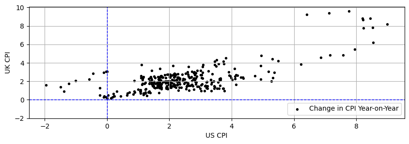

```python
# Creating the chart
fig, ax = plt.subplots(figsize=(10,3))
ax.scatter(cpi_us['CPIAUCSL'], cpi_uk['GBRCPIALLMINMEI'], color = 'black', s = 8, label = 'Change in CPI Year-on-Year')
# Adding a few aesthetic elements to the chart
ax.set_xlabel('US CPI')
ax.set_ylabel('UK CPI')
ax.axvline(x = 0, color='blue', linestyle = 'dashed', linewidth = 1)  # vertical line
ax.axhline(y = 0, color='blue', linestyle = 'dashed', linewidth = 1)  # horizontal line
ax.set_ylim(-2,)
# Calling the grid function for better interpretability
plt.grid()
# Calling the legend function to show the labels
plt.legend()
# Showing the plot
plt.show()
```

## What are Bars?

In the context of **financial data structures**, the term **BAR** refers to a fundamental unit of time-based price data used primarily in **technical analysis** and charting. A "bar" aggregates market data over a specific period, such as a minute, an hour, a day, or even a week, to represent price movements for that duration. Generally, each bar contains four key price components:

1. **Open Price**: The price at which the first trade occurred during the bar's time period.
2. **High Price**: The highest price reached during the bar's time period.
3. **Low Price**: The lowest price reached during the bar's time period.
4. **Close Price**: The price at which the last trade occurred during the bar's time period.

Together, these four prices form what is known as an **OHLC** bar (Open-High-Low-Close). Each bar also includes a **volume** component, representing the total quantity of assets traded during that period.

### Visual Representation of a BAR

- **Body**: A vertical line between the high and low prices indicates the price range for the time period.
- **Tick marks**:
  - A small horizontal tick to the left represents the **open price**.
  - A small horizontal tick to the right represents the **close price**.

[figure not shown]

### Applications of BAR in Financial Data Structures

1. **Charting and Visualization**: Bars are used to create bar charts, where each bar shows price movement for a set period. This is useful for visualizing trends over time.
2. **Technical Indicators**: Bars provide inputs for calculating indicators such as moving averages, Relative Strength Index (RSI), Bollinger Bands, etc.
3. **Trading Strategies**: Traders analyze bar data to identify patterns like price breakouts, reversals, or continuation patterns.
4. **Aggregation of Data**: Bars can be aggregated into different timeframes (e.g., 1-minute bars into 15-minute bars, daily bars into weekly bars).

### Types of Bars

- **Time-Based Bars**: Aggregated based on fixed time intervals (e.g., 1 minute, 1 hour, 1 day).
- **Volume-Based Bars**: A new bar is formed after a specified number of units are traded.
- **Range Bars**: Created when the price moves a specified range (e.g., 10 points).
- **Tick Bars**: A bar is created after a certain number of trades (e.g., 100 trades).

The **BAR** concept, while simple, is a powerful way to represent market data efficiently and serves as the foundation for most financial data structures used in trading systems and analytics.

## Yahoo! Finance

Yahoo Finance is a widely used platform for accessing financial market data, including stock prices, historical data, and company financials. By using the `yfinance` Python library, we can programmatically access this data and process it with pandas.

**Import Required Libraries**

Begin by importing the necessary libraries:

```python
import yfinance as yf
```

### Stocks

**Single Ticker**

To download historical data for a single stock. This returns a pandas DataFrame containing open, high, low, close, volume, and adjusted close prices.

```python
# Download historical data for Apple (AAPL)
apple_data = yf.download("AAPL", start="2020-01-01", end="2022-01-01")
apple_data.head()
```

```
[*********************100%%**********************]  1 of 1 completed
```

| Date | Open | High | Low | Close | Adj Close | Volume |
| --- | --- | --- | --- | --- | --- | --- |
| 2020-01-02 | 74.059998 | 75.150002 | 73.797501 | 75.087502 | 72.716072 | 135480400 |
| 2020-01-03 | 74.287498 | 75.144997 | 74.125000 | 74.357498 | 72.009102 | 146322800 |
| 2020-01-06 | 73.447502 | 74.989998 | 73.187500 | 74.949997 | 72.582901 | 118387200 |
| 2020-01-07 | 74.959999 | 75.224998 | 74.370003 | 74.597504 | 72.241531 | 108872000 |
| 2020-01-08 | 74.290001 | 76.110001 | 74.290001 | 75.797501 | 73.403648 | 132079200 |

```python
# Download historical data for Apple (AAPL)
apple_data = yf.download("AAPL", start="2024-11-01", end="2025-01-31")
apple_data.head()
```

```
[*********************100%%**********************]  1 of 1 completed
```

| Date | Open | High | Low | Close | Adj Close | Volume |
| --- | --- | --- | --- | --- | --- | --- |
| 2024-11-01 | 220.970001 | 225.350006 | 220.270004 | 222.910004 | 222.420471 | 65276700 |
| 2024-11-04 | 220.990005 | 222.789993 | 219.710007 | 222.009995 | 221.522446 | 44944500 |
| 2024-11-05 | 221.800003 | 223.949997 | 221.139999 | 223.449997 | 222.959290 | 28111300 |
| 2024-11-06 | 222.610001 | 226.070007 | 221.190002 | 222.720001 | 222.230896 | 54561100 |
| 2024-11-07 | 224.630005 | 227.880005 | 224.570007 | 227.479996 | 226.980438 | 42137700 |

```python
# Ensure all values are numeric
apple_data = apple_data.apply(pd.to_numeric, errors='coerce')
# Drop rows with NaN values
apple_data.dropna(inplace=True)
# mplfinance requires the DataFrame's index to be in DateTime format.
apple_data.index = pd.to_datetime(apple_data.index)
print(apple_data.dtypes)
```

```
Open         float64
High         float64
Low          float64
Close        float64
Adj Close    float64
Volume         int64
dtype: object
```

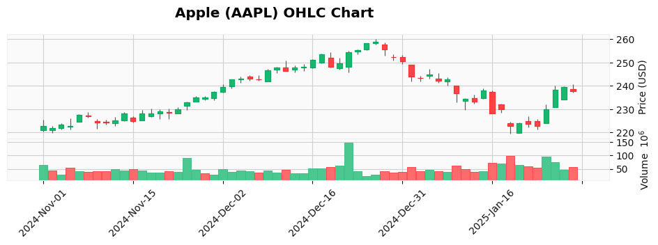

```python
# Plot the OHLC chart
mpf.plot(
    apple_data,
    type='candle',  # 'candle' for candlestick chart
    style='yahoo',  # Yahoo Finance style
    title='Apple (AAPL) OHLC Chart',
    ylabel='Price (USD)',
    volume=True,    # Include volume in the plot
    figsize=(12, 3) # Set the size of the plot
)
```

**Multiple Tickers**

To fetch data for multiple stocks:

```python
tickers = ["AAPL", "MSFT", "GOOGL"]
data = yf.download(tickers, start="2020-01-01", end="2023-12-31")
data.head()
```

```
[*********************100%%**********************]  3 of 3 completed
```

| Price Ticker Date | Adj Close AAPL | Adj Close GOOGL | Adj Close MSFT | Close AAPL | Close GOOGL | Close MSFT | High AAPL | High GOOGL | High MSFT | Low AAPL | Low GOOGL | Low MSFT | Open AAPL | Open GOOGL | Open MSFT | Volume AAPL | Volume GOOGL | Volume MSFT |
| --- | --- | --- | --- | --- | --- | --- | --- | --- | --- | --- | --- | --- | --- | --- | --- | --- | --- | --- |
| 2020-01-02 | 72.716064 | 68.186821 | 153.630661 | 75.087502 | 68.433998 | 160.619995 | 75.150002 | 68.433998 | 160.729996 | 73.797501 | 67.324501 | 158.330002 | 74.059998 | 67.420502 | 158.779999 | 135480400 | 27278000 | 22622100 |
| 2020-01-03 | 72.009109 | 67.830109 | 151.717728 | 74.357498 | 68.075996 | 158.619995 | 75.144997 | 68.687500 | 159.949997 | 74.125000 | 67.365997 | 158.059998 | 74.287498 | 67.400002 | 158.320007 | 146322800 | 23408000 | 21116200 |
| 2020-01-06 | 72.582909 | 69.638054 | 152.109879 | 74.949997 | 69.890503 | 159.029999 | 74.989998 | 69.916000 | 159.100006 | 73.187500 | 67.550003 | 156.509995 | 73.447502 | 67.581497 | 157.080002 | 118387200 | 46768000 | 20813700 |
| 2020-01-07 | 72.241562 | 69.503548 | 150.722977 | 74.597504 | 69.755501 | 157.580002 | 75.224998 | 70.175003 | 159.669998 | 74.370003 | 69.578003 | 157.320007 | 74.959999 | 70.023003 | 159.320007 | 108872000 | 34330000 | 21634100 |
| 2020-01-08 | 73.403641 | 69.998245 | 153.123779 | 75.797501 | 70.251999 | 160.089996 | 76.110001 | 70.592499 | 160.800003 | 74.290001 | 69.631500 | 157.949997 | 74.290001 | 69.740997 | 158.929993 | 132079200 | 35314000 | 27746500 |

```python
close_prices = data["Close"]
close_prices.head()
```

| Ticker Date | AAPL | GOOGL | MSFT |
| --- | --- | --- | --- |
| 2020-01-02 | 75.087502 | 68.433998 | 160.619995 |
| 2020-01-03 | 74.357498 | 68.075996 | 158.619995 |
| 2020-01-06 | 74.949997 | 69.890503 | 159.029999 |
| 2020-01-07 | 74.597504 | 69.755501 | 157.580002 |
| 2020-01-08 | 75.797501 | 70.251999 | 160.089996 |

**Calculating Daily Returns**

```python
daily_returns = apple_data["Adj Close"].pct_change()
daily_returns.head()
```

```
Date
2024-11-01         NaN
2024-11-04   -0.004038
2024-11-05    0.006486
2024-11-06   -0.003267
2024-11-07    0.021372
Name: Adj Close, dtype: float64
```

**Resampling Data**

Resample the data to a monthly and weekly frequency:

```python
monthly_data = apple_data.resample("M").mean()
monthly_data.head()
```

| Date | Open | High | Low | Close | Adj Close | Volume |
| --- | --- | --- | --- | --- | --- | --- |
| 2024-11-30 | 226.722501 | 229.073000 | 225.626002 | 227.810499 | 227.498904 | 4.458203e+07 |
| 2024-12-31 | 248.331430 | 250.811429 | 246.873808 | 249.322856 | 249.049032 | 4.656743e+07 |
| 2025-01-31 | 234.466841 | 237.066842 | 231.754211 | 234.512631 | 234.255072 | 5.785351e+07 |

```python
monthly_data = apple_data.resample("W").mean()
monthly_data.head()
```

| Date | Open | High | Low | Close | Adj Close | Volume |
| --- | --- | --- | --- | --- | --- | --- |
| 2024-11-03 | 220.970001 | 225.350006 | 220.270004 | 222.910004 | 222.420471 | 65276700.0 |
| 2024-11-10 | 223.440002 | 225.870001 | 222.604004 | 224.523999 | 224.080762 | 41616680.0 |
| 2024-11-17 | 224.995999 | 226.745996 | 223.378000 | 225.359998 | 225.112494 | 44763540.0 |
| 2024-11-24 | 227.445999 | 230.142001 | 226.298001 | 228.738000 | 228.486783 | 39268800.0 |
| 2024-12-01 | 233.517502 | 235.580002 | 232.712502 | 235.047497 | 234.789352 | 49529700.0 |

**Merging DataFrames**

If you have additional data sources to combine:

```python
other_data = pd.DataFrame({"Date": ["2024-11-01", "2024-11-05"], "Extra": [1, 2]})
other_data["Date"] = pd.to_datetime(other_data["Date"])
other_data.head()
```

|  | Date | Extra |
| --- | --- | --- |
| 0 | 2024-11-01 | 1 |
| 1 | 2024-11-05 | 2 |

```python
merged_data = pd.merge(apple_data.reset_index(), other_data, how="left", on="Date")
merged_data.head()
```

|  | Date | Open | High | Low | Close | Adj Close | Volume | Extra |
| --- | --- | --- | --- | --- | --- | --- | --- | --- |
| 0 | 2024-11-01 | 220.970001 | 225.350006 | 220.270004 | 222.910004 | 222.420471 | 65276700 | 1.0 |
| 1 | 2024-11-04 | 220.990005 | 222.789993 | 219.710007 | 222.009995 | 221.522446 | 44944500 | NaN |
| 2 | 2024-11-05 | 221.800003 | 223.949997 | 221.139999 | 223.449997 | 222.959290 | 28111300 | 2.0 |
| 3 | 2024-11-06 | 222.610001 | 226.070007 | 221.190002 | 222.720001 | 222.230896 | 54561100 | NaN |
| 4 | 2024-11-07 | 224.630005 | 227.880005 | 224.570007 | 227.479996 | 226.980438 | 42137700 | NaN |

**Filtering Specific Date Ranges**

```python
filtered_data = merged_data[(merged_data['Date'] >= "2024-11-01") & (merged_data['Date'] <= "2024-12-07")]
filtered_data.head()
```

|  | Date | Open | High | Low | Close | Adj Close | Volume | Extra |
| --- | --- | --- | --- | --- | --- | --- | --- | --- |
| 0 | 2024-11-01 | 220.970001 | 225.350006 | 220.270004 | 222.910004 | 222.420471 | 65276700 | 1.0 |
| 1 | 2024-11-04 | 220.990005 | 222.789993 | 219.710007 | 222.009995 | 221.522446 | 44944500 | NaN |
| 2 | 2024-11-05 | 221.800003 | 223.949997 | 221.139999 | 223.449997 | 222.959290 | 28111300 | 2.0 |
| 3 | 2024-11-06 | 222.610001 | 226.070007 | 221.190002 | 222.720001 | 222.230896 | 54561100 | NaN |
| 4 | 2024-11-07 | 224.630005 | 227.880005 | 224.570007 | 227.479996 | 226.980438 | 42137700 | NaN |

**Plotting Closing Prices**

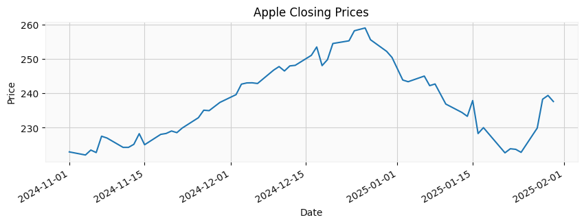

```python
plt.figure(figsize=(10,3))
apple_data["Close"].plot(title="Apple Closing Prices")
plt.xlabel("Date")
plt.ylabel("Price")
plt.show()
```

[figure not shown]

```python
close_prices.plot(title="Closing Prices of Selected Stocks",figsize=(10,3))
plt.xlabel("Date")
plt.ylabel("Price")
plt.legend(tickers)
plt.show()
```

### Market Indices

Here are the Yahoo Finance ticker symbols for the some financial indices:

| Index Name | Ticker Symbol |
| --- | --- |
| NASDAQ 100 - PRICE INDEX | ^NDX |
| NASDAQ COMPOSITE - PRICE INDEX | ^IXIC |
| S&P 500 COMPOSITE - PRICE INDEX | ^GSPC |

Please note that Yahoo Finance uses specific ticker symbols for indices, often prefixed with a caret (^). These symbols are case-sensitive and should be entered exactly as shown.

```python
tickers = ["^NDX", "^IXIC", "^GSPC"]
index = yf.download(tickers, start="2014-01-01", end="2022-12-31")
index.head()
```

```
[*********************100%%**********************]  3 of 3 completed
```

| Price Ticker Date | Adj Close ^GSPC | Adj Close ^IXIC | Adj Close ^NDX | Close ^GSPC | Close ^IXIC | Close ^NDX | High ^GSPC | High ^IXIC | High ^NDX | Low ^GSPC | Low ^IXIC | Low ^NDX | Open ^GSPC | Open ^IXIC | Open ^NDX | Volume ^GSPC | Volume ^IXIC | Volume ^NDX |
| --- | --- | --- | --- | --- | --- | --- | --- | --- | --- | --- | --- | --- | --- | --- | --- | --- | --- | --- |
| 2014-01-02 | 1831.979980 | 4143.069824 | 3563.570068 | 1831.979980 | 4143.069824 | 3563.570068 | 1845.859985 | 4160.959961 | 3577.030029 | 1827.739990 | 4131.790039 | 3553.649902 | 1845.859985 | 4160.029785 | 3575.600098 | 3080600000 | 1738820000 | 1738820000 |
| 2014-01-03 | 1831.369995 | 4131.910156 | 3538.729980 | 1831.369995 | 4131.910156 | 3538.729980 | 1838.239990 | 4152.959961 | 3567.510010 | 1829.130005 | 4124.959961 | 3537.610107 | 1833.209961 | 4148.560059 | 3564.939941 | 2774270000 | 1667480000 | 1667480000 |
| 2014-01-06 | 1826.770020 | 4113.680176 | 3526.959961 | 1826.770020 | 4113.680176 | 3526.959961 | 1837.160034 | 4139.779785 | 3542.520020 | 1823.729980 | 4103.750000 | 3512.449951 | 1832.310059 | 4137.029785 | 3539.020020 | 3294850000 | 2292840000 | 2292840000 |
| 2014-01-07 | 1837.880005 | 4153.180176 | 3557.850098 | 1837.880005 | 4153.180176 | 3557.850098 | 1840.099976 | 4158.180176 | 3562.989990 | 1828.709961 | 4126.479980 | 3535.500000 | 1828.709961 | 4128.569824 | 3539.290039 | 3511750000 | 2278220000 | 2278220000 |
| 2014-01-08 | 1837.489990 | 4165.609863 | 3567.540039 | 1837.489990 | 4165.609863 | 3567.540039 | 1840.020020 | 4171.750000 | 3575.149902 | 1831.400024 | 4145.000000 | 3551.120117 | 1837.900024 | 4154.279785 | 3558.300049 | 3652140000 | 2345220000 | 2345220000 |

**Save to CSV**

```python
import os

path_name = '.'
file_name = 'index_data.csv'
file_name = os.path.join(path_name, file_name)
index.to_csv(file_name)

print(f"File saved to {file_name}")
```

```
File saved to .\index_data.csv
```

**Other Examples**

Other very simple examples include Stock Price Correlation Analysis and Portfolio Performance

```python
returns = close_prices.pct_change()
correlation = returns.corr()
print(correlation)
```

```
Ticker      AAPL     GOOGL      MSFT
Ticker
AAPL    1.000000  0.691082  0.776784
GOOGL   0.691082  1.000000  0.772333
MSFT    0.776784  0.772333  1.000000
```

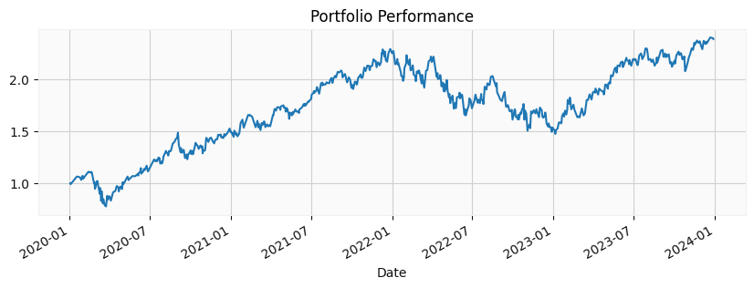

```python
weights = [0.4, 0.4, 0.2]  # Allocation weights for AAPL, MSFT, GOOGL
portfolio_returns = (returns * weights).sum(axis=1)
portfolio_cumulative = (1 + portfolio_returns).cumprod()
portfolio_cumulative.plot(title="Portfolio Performance", figsize=(10,3))
plt.show()
```

### Forex

```python
# Define major Forex pairs
forex_pairs = ["EURUSD=X", "GBPUSD=X", "AUDUSD=X", "USDCAD=X"]

# Download last 1 year of Forex data
forex_data = yf.download(forex_pairs, period="1y", interval="1d")

# Extract closing prices
forex_closing_prices = forex_data['Adj Close']
```

```
[*********************100%%**********************]  4 of 4 completed
```

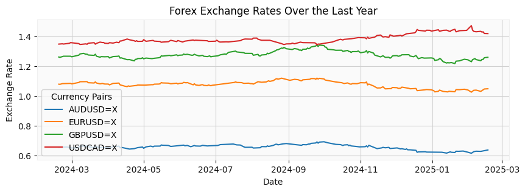

```python
# Plot Forex exchange rates over time
plt.figure(figsize=(10, 3))
for pair in forex_closing_prices.columns:
    plt.plot(forex_closing_prices.index, forex_closing_prices[pair], label=pair)
# Formatting the plot
plt.title("Forex Exchange Rates Over the Last Year")
plt.xlabel("Date")
plt.ylabel("Exchange Rate")
plt.legend(title="Currency Pairs")
plt.grid(True)
# Show the plot
plt.show()
```

### Options

Yahoo Finance also provides financial option data, which can be accessed programmatically using the `yfinance` library. Below is a step-by-step guide on how to download and analyze option data from Yahoo Finance.

**Access Option Chains**

Each stock has a set of options available for different expiration dates. You can fetch these option chains using the `Ticker` object in `yfinance`. This will return a list of all available expiration dates for the options.

```python
#
# Fetching Option Expiration Dates
#
ticker = yf.Ticker("AAPL")  # Replace "AAPL" with your desired stock ticker
expiration_dates = ticker.options
print(expiration_dates)
```

```
('2025-02-21', '2025-02-28', '2025-03-07', '2025-03-14', '2025-03-21', '2025-03-28', '2025-04-04', '2025-04-17', '2025-05-16', '2025-06-20', '2025-07-18', '2025-08-15', '2025-09-19', '2025-10-17', '2025-12-19', '2026-01-16', '2026-03-20', '2026-06-18', '2026-12-18', '2027-01-15', '2027-06-17')
```

**Download Option Data for a Specific Expiration Date**

Once you have the expiration dates, you can fetch the options data (both calls and puts) for a specific expiration date. The data for calls and puts will be returned as pandas DataFrames, containing columns such as:

```
- contractSymbol: The option symbol.
- strike        : The strike price.
- lastPrice     : The last traded price of the option.
- bid           : The bid price.
- ask           : The ask price.
- volume        : The trading volume.
- openInterest  : The number of open contracts.
```

```python
#
# Fetching Option Chains (Calls and Puts)
#
# Specify the expiration date
expiration_date = expiration_dates[0]  # Example: Use the first available date

# Fetch options data
options_data = ticker.option_chain(expiration_date)

# Separate calls and puts data
calls = options_data.calls
puts = options_data.puts
```

```python
# Display the data
print("Calls:\n")
calls.head()
```

```
Calls:
```

|  | contractSymbol | lastTradeDate | strike | lastPrice | bid | ask | change | percentChange | volume | openInterest | impliedVolatility | inTheMoney | contractSize | currency |
| --- | --- | --- | --- | --- | --- | --- | --- | --- | --- | --- | --- | --- | --- | --- |
| 0 | AAPL250221C00100000 | 2025-02-12 18:40:34+00:00 | 100.0 | 135.70 | 144.00 | 145.40 | 0.0 | 0.0 | 5.0 | 13.0 | 3.023440 | True | REGULAR | USD |
| 1 | AAPL250221C00105000 | 2024-12-27 16:14:26+00:00 | 105.0 | 149.85 | 130.65 | 131.65 | 0.0 | 0.0 | 1.0 | 4.0 | 0.000010 | True | REGULAR | USD |
| 2 | AAPL250221C00110000 | 2025-02-11 19:07:05+00:00 | 110.0 | 123.80 | 134.00 | 135.40 | 0.0 | 0.0 | 1.0 | 1.0 | 2.718753 | True | REGULAR | USD |
| 3 | AAPL250221C00115000 | 2025-01-27 16:32:05+00:00 | 115.0 | 113.65 | 128.95 | 130.40 | 0.0 | 0.0 | 6.0 | 1.0 | 2.492191 | True | REGULAR | USD |
| 4 | AAPL250221C00120000 | 2025-01-28 18:41:22+00:00 | 120.0 | 118.95 | 124.00 | 125.40 | 0.0 | 0.0 | 1.0 | 0.0 | 2.441410 | True | REGULAR | USD |

```python
print("Puts:\n")
puts.head()
```

```
Puts:
```

[output not shown]

**Automate the Process for All Expiration Dates**

If you want to fetch options data for all expiration dates...

```python
# Initialize empty lists to store call and put option data
all_calls = []
all_puts = []
# Iterate over each expiration date in the list
for date in expiration_dates:
    # Retrieve the option chain data for the given expiration date
    options = ticker.option_chain(date)
    # Extract call and put options separately
    calls, puts = options.calls, options.puts
    # Add a new column to each DataFrame to store the expiration date
    calls['expirationDate'] = date
    puts['expirationDate'] = date
    # Append the modified DataFrames to the respective lists
    all_calls.append(calls)
    all_puts.append(puts)
# Combine all collected call options into a single DataFrame
all_calls_data = pd.concat(all_calls)
# Combine all collected put options into a single DataFrame
all_puts_data = pd.concat(all_puts)
# Save the combined call options data to a CSV file
all_calls_data.to_csv("all_calls_data.csv", index=False)
# Save the combined put options data to a CSV file
all_puts_data.to_csv("all_puts_data.csv", index=False)
```

**Limitations**

yfinance does not provide historical options data; you can only access current data for the available expiration dates.

### What is an f-string in Python?

An **f-string** (formatted string literal) is a way to embed expressions inside string literals using curly braces `{}`. It was introduced in **Python 3.6** and provides a concise, readable, and efficient way to format strings.

**Syntax of f-strings**

An f-string is prefixed with `f` (or `F`), and variables or expressions are placed inside `{}`:

```
name = "Alice"
age = 30
formatted_string = f"My name is {name} and I am {age} years old."
print(formatted_string)
```

**Output:**

```
My name is Alice and I am 30 years old.
```

**Key Features of f-strings**

1. **Variable Interpolation**  
   Directly insert variables into strings:

   ```
   x = 5
   y = 10
   print(f"The sum of {x} and {y} is {x + y}.")
   ```

   **Output:**

   ```
   The sum of 5 and 10 is 15.
   ```

2. **Expression Evaluation**  
   You can use **any valid Python expression** inside `{}`:

   ```
   print(f"The square of 4 is {4**2}.")
   ```

   **Output:**

   ```
   The square of 4 is 16.
   ```

3. **Formatting Numbers**  
   Use format specifiers like `.2f` (two decimal places), `,` (thousands separator), etc.:

   ```
   pi = 3.14159
   print(f"Pi rounded to 2 decimal places: {pi:.2f}")
   print(f"Large number with commas: {1000000:,}")
   ```

   **Output:**

   ```
   Pi rounded to 2 decimal places: 3.14
   Large number with commas: 1,000,000
   ```

4. **Padding & Alignment**  
   Align text and numbers:

   ```
   print(f"{'Left':<10} | {'Center':^10} | {'Right':>10}")
   ```

   **Output:**

   ```
   Left       |   Center   |      Right
   ```

5. **Calling Functions Inside f-strings**

   ```
   def greet(name):
       return f"Hello, {name}!"

   print(f"{greet('Bob')}")
   ```

   **Output:**

   ```
   Hello, Bob!
   ```

**Comparison with Other Formatting Methods**

| **Method** | **Example** | **Output** |
| --- | --- | --- |
| **f-string (Python 3.6+)** | `f"Hello, {name}!"` | `Hello, Alice!` |
| **`format()` method** | `"Hello, {}!".format(name)` | `Hello, Alice!` |
| **Old `%` formatting** | `"Hello, %s!" % name` | `Hello, Alice!` |

🔹 **f-strings are faster and more readable** than `.format()` and `%` formatting.

**Conclusion**

✅ **f-strings** make string formatting **simpler, more readable, and more powerful**.

✅ They **support expressions, number formatting, and function calls**.

✅ They are the **recommended** way to format strings in modern Python (≥3.6). 🚀

### What is the Meaning of the Format in the World Bank Example

The lambda function in the code:

```
lambda x: f"{x:,.0f}"
```

is using **Python’s formatted string literals (f-strings)** along with **format specifiers** to format the GDP values by inserting a **comma (`,`) every three digits**.

**Breaking Down the Format Specifier `{x:,.0f}`**

The format specifier inside the **f-string** (`f""`) follows this structure:

- `{x:,.0f}`
  - `:` → Starts the format specifier.
  - `,` → Adds a **thousands separator** (inserting commas every three digits).
  - `.0f` → Formats the number as a **floating-point number with zero decimal places** (`.0` means no decimals, `f` stands for fixed-point notation).

**How the Formatting Works**

Consider an example where `x = 21000000000000`:

```
x = 21000000000000
formatted_x = f"{x:,.0f}"
print(formatted_x)
```

**Output:**

```
21,000,000,000,000
```

- The comma `,` ensures that **every three digits** from the right are grouped together.
- `.0f` removes any decimal places, converting it to an **integer-like format**.

**More Examples**

| **Number** | **Formatted Output (`{x:,.0f}`)** |
| --- | --- |
| `1234567.89` | `1,234,568` (Rounded to zero decimals) |
| `987654321` | `987,654,321` |
| `15000.75` | `15,001` (Rounded) |
| `99999999999` | `99,999,999,999` |

If we wanted **two decimal places**, we could use `{x:,.2f}`:

```
x = 1234567.891
formatted_x = f"{x:,.2f}"
print(formatted_x)
```

**Output:**

```
1,234,567.89
```

Here, `.2f` keeps **two decimal places**.

**Conclusion**

- The lambda function applies `f"{x:,.0f}"` to each GDP value.
- The `,` ensures **thousands separators**.
- The `.0f` ensures **no decimal places**.
- The result is a **human-friendly GDP format**, making large numbers **easier to read**. 🚀

### How use the `diff` method in `pandas`

**Understanding the Pandas Instruction:**

```
vix = vix.diff(periods=1, axis=0)
```

This line **computes the difference between consecutive rows** in a Pandas DataFrame or Series named `vix`.

**Breaking Down the Parameters**

1. **`.diff(periods=1, axis=0)`**
- `periods=1` → Computes the difference between each value and the value **one row before**.
- `axis=0` → Operates **row-wise** (default), meaning it subtracts the previous row from the current row.

**Example 1: Using `.diff()` on a Pandas Series**

**Original VIX Series:**

```
import pandas as pd

data = {'VIX': [15.2, 16.8, 18.1, 17.5, 19.0]}
vix = pd.DataFrame(data)

print(vix)
```

**Output:**

```
    VIX
0  15.2
1  16.8
2  18.1
3  17.5
4  19.0
```

**Applying `.diff(periods=1, axis=0)`:**

```
vix = vix.diff(periods=1, axis=0)
print(vix)
```

**Output:**

```
    VIX
0   NaN   # First row has no previous value, so it's NaN
1   1.6   # 16.8 - 15.2
2   1.3   # 18.1 - 16.8
3  -0.6   # 17.5 - 18.1
4   1.5   # 19.0 - 17.5
```

**Example 2: Using `.diff()` on a DataFrame with Multiple Columns**

If `vix` is a DataFrame with multiple columns:

```
data = {
    'VIX': [15.2, 16.8, 18.1, 17.5, 19.0],
    'SP500': [4500, 4520, 4535, 4510, 4540]
}
vix = pd.DataFrame(data)

# Compute row-wise differences
vix_diff = vix.diff(periods=1, axis=0)

print(vix_diff)
```

**Output:**

```
    VIX  SP500
0   NaN    NaN
1   1.6   20.0
2   1.3   15.0
3  -0.6  -25.0
4   1.5   30.0
```

Each column is processed **independently**.

**Key Takeaways**

- `.diff(periods=1, axis=0)` computes **row-wise differences**.
- **First row always returns `NaN`**, since there’s no previous value to subtract.
- If `periods=n`, it computes the difference with the **n-th previous row**.
- Works on **both Series and DataFrames**.

**Alternative Uses**

**1. Computing Differences Over Longer Periods**

```
vix.diff(periods=2)  # Difference with the row 2 periods before
```

**2. Column-Wise Differences (`axis=1`)**

If `axis=1` is used, differences are computed **between columns** instead of rows:

```
vix.diff(axis=1)
```

## Reference and Credits

Here is a literature reference for using **pandas** to download financial data, specifically with `pandas_datareader` and `yfinance`:

**McKinney, W. (2017).** *Python for Data Analysis: Data Wrangling with Pandas, NumPy, and Jupyter.* O'Reilly Media.

📌 **Summary:**  
This book provides a comprehensive guide to using `pandas` for financial data analysis, including time series manipulation and integration with external data sources like Yahoo Finance, Quandl, and other APIs.

Additionally, for a more academic reference:

**Wes McKinney. (2012).** *Python for Data Analysis.* O’Reilly Media.  
**DOI:** 10.5555/2461238

This book covers practical techniques for data analysis using `pandas`, including how to fetch and process financial data.

For specific documentation references:

- **Pandas Official Documentation:**  
  https://pandas.pydata.org/docs/
- **pandas_datareader Documentation:**  
  https://pandas-datareader.readthedocs.io/en/latest/